# Louisiana TOPS Scholarship

2026-07-27

In a rare case of bipartisanship, the Democratic congress led by Charles R. McDonald teamed with Republican businessman Patrick Taylor to promote the “Taylor Plan”, which would later become TOPS. The plan was simple: making education more affordable by completely waiving tuition (sometimes on top of a generous stipend). Of course, the tapestry of Louisiana has changed rapidly since 1989 when the plan was first drafted.

While states like Georgia fund in-state scholarships via the state’s lottery system, TOPS is completely funded by the government, costing around 270$ million per year. Which that price tag, many congressman has called into question the return on investment in Louisiana’s elite students.

As a researcher, I believe in using data tools for social good. Having grown up in Louisiana, I have seen how beneficial TOPS is. The scholarship can be the difference between just eking out a living during college to thriving. Additionally, the award is sometimes the deciding factor on whether or not some bright students attend college at all. Because TOPS is a strictly merit-based scholarship, some have questioned whether recipients actually need the tuition waiver, preferring the money to go to other need-based scholarship programs. I believe that there, too, TOPS serves a purpose: if an individual achieves success due to Louisiana’s K-12 investment, shouldn’t the state try to retain that talent? Indeed, one core mission of TOPS is to “keep Louisiana’s best and brightest in the State to pursue postsecondary educational opportunities and become productive members of Louisiana’s workforce.”

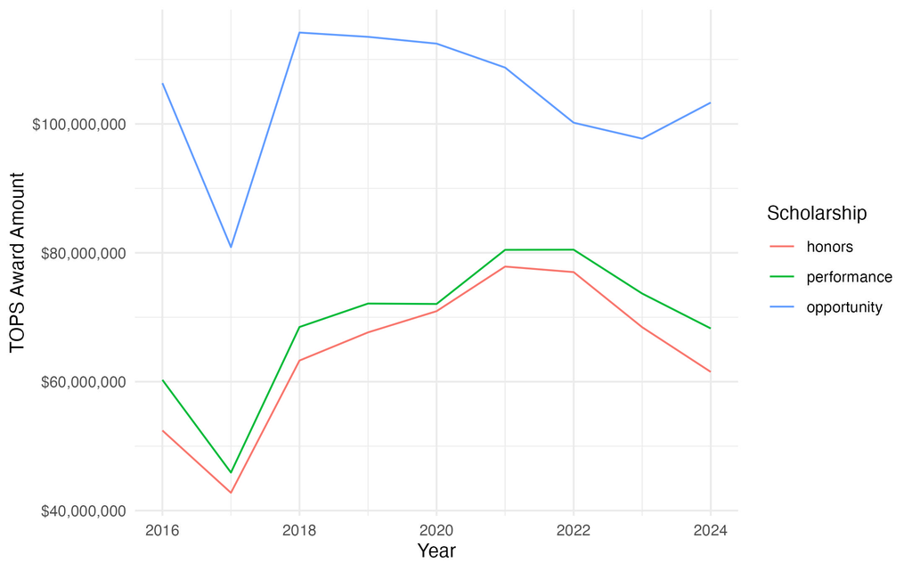

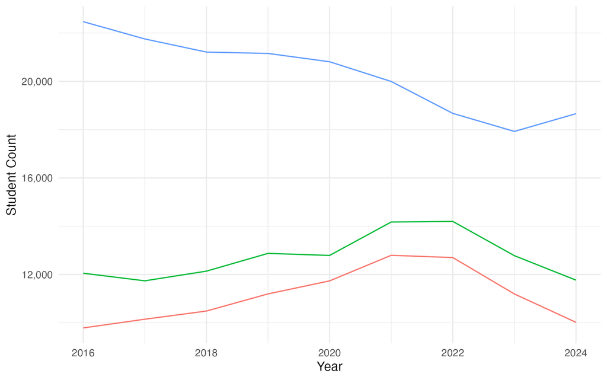